# Modelo Lineal Multivariado - Clase 5

Cecilia Oliva

27/06/2023

# Modelo lineal mulivariado

## Modelo aditivo

### Ejemplo de datos de glucosa en pacientes

La descripción de las variables es:

glucosa: valor de glucosa en sangre,

ejercicio: 1 si el paciente hace ejercicio, 0 si no hace,

bmi: indice de masa corporal (body mass index),

peso.evo: la evolución del peso del paciente en el último año. Es una variable categórica que representa: disminución de peso en el último año de 7% o más (1), sin cambio de peso en el último año, menos de 7% de diferencia (2), aumento de peso en el último año de 7% o más (3).

```r
azucar <- read.table(file = "azucar.txt", header = TRUE)
head(azucar)
```

|  | glucosa | ejercicio | bmi | peso.evo |
| --- | --- | --- | --- | --- |
| 1 | 101 | 0 | 27.47 | 2 |
| 2 | 91 | 1 | 19.59 | 2 |
| 3 | 90 | 1 | 27.05 | 3 |
| 4 | 81 | 1 | 21.85 | 1 |
| 5 | 91 | 1 | 23.74 | 3 |
| 6 | 99 | 1 | 25.72 | 3 |

```r
names(azucar)
```

```
## [1] "glucosa"   "ejercicio" "bmi"       "peso.evo"
```

```r
dim(azucar)
```

```
## [1] 220   4
```

```r
Ievo<-factor(azucar$peso.evo) #convierte a la variable en factor
contrasts(Ievo) #da la codificación
```

```
##   2 3
## 1 0 0
## 2 1 0
## 3 0 1
```

Probamos un modelo lineal univariado. Cuando la covariable es binaria no hace falta agregarla al modelo como factor.

```r
ajuste1<-lm(glucosa ~ ejercicio, data = azucar)
summary(ajuste1)
```

```
##
## Call:
## lm(formula = glucosa ~ ejercicio, data = azucar)
##
## Residuals:
##     Min      1Q  Median      3Q     Max
## -18.914  -6.487  -0.487   5.656  28.513
##
## Coefficients:
##             Estimate Std. Error t value Pr(>|t|)
## (Intercept)  98.9143     0.8512 116.212  < 2e-16 ***
## ejercicio    -7.4273     1.1773  -6.309 1.54e-09 ***
## ---
## Signif. codes:  0 '***' 0.001 '**' 0.01 '*' 0.05 '.' 0.1 ' ' 1
##
## Residual standard error: 8.722 on 218 degrees of freedom
## Multiple R-squared:  0.1544, Adjusted R-squared:  0.1505
## F-statistic:  39.8 on 1 and 218 DF,  p-value: 1.545e-09
```

Consideramos ahora además la variable numérica del índice de masa corporal. Observamos que aumenta el coeficiente de determinación $R^2$.

```r
ajuste2<-lm(glucosa ~ ejercicio + bmi, data = azucar)
summary(ajuste2)
```

```
##
## Call:
## lm(formula = glucosa ~ ejercicio + bmi, data = azucar)
##
## Residuals:
##      Min       1Q   Median       3Q      Max
## -17.4179  -6.0342  -0.5269   5.1501  23.7109
##
## Coefficients:
##             Estimate Std. Error t value Pr(>|t|)
## (Intercept)  84.4141     3.2336  26.105  < 2e-16 ***
## ejercicio    -6.4879     1.1437  -5.673 4.46e-08 ***
## bmi           0.5227     0.1128   4.633 6.20e-06 ***
## ---
## Signif. codes:  0 '***' 0.001 '**' 0.01 '*' 0.05 '.' 0.1 ' ' 1
##
## Residual standard error: 8.339 on 217 degrees of freedom
## Multiple R-squared:  0.2305, Adjusted R-squared:  0.2234
## F-statistic:  32.5 on 2 and 217 DF,  p-value: 4.491e-13
```

Probamos usando sólo la variable categórica de evolución del peso. Notar la diferencia en el coeficiente de determinación $R^2$.

```r
ajuste3<-lm(glucosa ~ Ievo,data=azucar)
summary(ajuste3)
```

```
##
## Call:
## lm(formula = glucosa ~ Ievo, data = azucar)
##
## Residuals:
##      Min       1Q   Median       3Q      Max
## -19.5556  -6.3434  -0.9126   5.7273  25.7304
##
## Coefficients:
##             Estimate Std. Error t value Pr(>|t|)
## (Intercept)   88.273      1.564  56.449  < 2e-16 ***
## Ievo2          6.283      1.888   3.327  0.00103 **
## Ievo3          8.997      1.774   5.072 8.45e-07 ***
## ---
## Signif. codes:  0 '***' 0.001 '**' 0.01 '*' 0.05 '.' 0.1 ' ' 1
##
## Residual standard error: 8.983 on 217 degrees of freedom
## Multiple R-squared:  0.1071, Adjusted R-squared:  0.09884
## F-statistic: 13.01 on 2 and 217 DF,  p-value: 4.607e-06
```

Incluimos al modelo anterior los valores del índice de masa corporal. Se observa aumento del coeficiente de determinación.

```r
ajuste4<-lm(glucosa ~ Ievo + bmi,data=azucar)
summary(ajuste4)
```

```
##
## Call:
## lm(formula = glucosa ~ Ievo + bmi, data = azucar)
##
## Residuals:
##      Min       1Q   Median       3Q      Max
## -18.8417  -5.4579  -0.5352   5.4125  25.1341
##
## Coefficients:
##             Estimate Std. Error t value Pr(>|t|)
## (Intercept)  72.0993     3.3764  21.354  < 2e-16 ***
## Ievo2         6.8023     1.7823   3.817 0.000177 ***
## Ievo3         8.4963     1.6744   5.074 8.38e-07 ***
## bmi           0.6068     0.1140   5.324 2.54e-07 ***
## ---
## Signif. codes:  0 '***' 0.001 '**' 0.01 '*' 0.05 '.' 0.1 ' ' 1
##
## Residual standard error: 8.466 on 216 degrees of freedom
## Multiple R-squared:  0.2107, Adjusted R-squared:  0.1997
## F-statistic: 19.21 on 3 and 216 DF,  p-value: 4.411e-11
```

Comparamos ambos modelos usando el comando anova.

```r
uno<-lm(glucosa ~ Ievo, data=azucar)
dos<-lm(glucosa ~ Ievo + bmi,data=azucar)
anova(uno,dos)
```

|  | Res.Df | RSS | Df | Sum of Sq | F | Pr(>F) |
| --- | --- | --- | --- | --- | --- | --- |
| 1 | 217 | 17510.97 | NA | NA | NA | NA |
| 2 | 216 | 15479.66 | 1 | 2031.31 | 28.34449 | 2.538976e-07 |

Se concluye que es significativamente mejor el modelo agregando la variable bmi.

## Modelo con interacción

### Ejemplo de datos de pulso

Consideremos datos sobre la frecuencia cardíaca o pulso medido a 40 personas antes y después de ejercitar. Se les pidió que registraran su pulso, luego que corrieran una milla, y luego volvieran a registrar su pulso. Además se registró su sexo, edad y si eran o no fumadores.

Y = pulso luego de correr una milla (Pulso2)

$X_1$ = pulso en reposo (Pulso1)

$X_2$ = 1 si la persona es mujer, 0 en caso contrario

$X_3$ = 1 si la persona fuma, 0 en caso contrario

$X_4$ = edad

Interesa explicar el pulso post-ejercicio, en función de algunas de las demás covariables. Es de interés saber si la edad, o el hábito de fumar inciden en él. La frecuencia cardíaca es el número de contracciones del corazón o pulsaciones por unidad de tiempo. Su medida se realiza en unas condiciones determinadas (reposo o actividad) y se expresa en latidos por minuto. Tanto el sexo como la condición de fumador son variables dummies o binarias. Las restantes son variables continuas.

```r
pulso<-read.table(file = "pulso.txt", header = TRUE)
head(pulso)
```

|  | edad | mujer | fuma | Pulso1 | Pulso2 |
| --- | --- | --- | --- | --- | --- |
| 1 | 31 | 0 | 1 | 62 | 126 |
| 2 | 20 | 1 | 1 | 78 | 154 |
| 3 | 28 | 0 | 0 | 64 | 128 |
| 4 | 29 | 1 | 0 | 96 | 155 |
| 5 | 21 | 0 | 1 | 66 | 128 |
| 6 | 27 | 1 | 1 | 96 | 165 |

```r
dim(pulso)#40  5
```

```
## [1] 40  5
```

Modelo aditivo con variables continua y categórica

```r
ajuste1<-lm(Pulso2~ Pulso1+mujer,data=pulso)
summary(ajuste1)
```

```
##
## Call:
## lm(formula = Pulso2 ~ Pulso1 + mujer, data = pulso)
##
## Residuals:
##      Min       1Q   Median       3Q      Max
## -16.1631  -6.7032   0.8996   4.7975  25.7114
##
## Coefficients:
##             Estimate Std. Error t value Pr(>|t|)
## (Intercept)  93.0970    12.5157   7.438 7.44e-09 ***
## Pulso1        0.5157     0.1715   3.007 0.004725 **
## mujer        12.7494     3.2468   3.927 0.000361 ***
## ---
## Signif. codes:  0 '***' 0.001 '**' 0.01 '*' 0.05 '.' 0.1 ' ' 1
##
## Residual standard error: 9.107 on 37 degrees of freedom
## Multiple R-squared:  0.5445, Adjusted R-squared:  0.5199
## F-statistic: 22.12 on 2 and 37 DF,  p-value: 4.803e-07
```

Modelo con interacción entre variables continua y categórica

```r
ajuste2<-lm(Pulso2~ Pulso1 * mujer,data=pulso)
summary(ajuste2)
```

```
##
## Call:
## lm(formula = Pulso2 ~ Pulso1 * mujer, data = pulso)
##
## Residuals:
##      Min       1Q   Median       3Q      Max
## -16.2954  -6.6283   0.6379   4.7712  25.8379
##
## Coefficients:
##              Estimate Std. Error t value Pr(>|t|)
## (Intercept)  95.42838   16.80929   5.677 1.88e-06 ***
## Pulso1        0.48334    0.23157   2.087    0.044 *
## mujer         7.05575   27.14749   0.260    0.796
## Pulso1:mujer  0.07402    0.35033   0.211    0.834
## ---
## Signif. codes:  0 '***' 0.001 '**' 0.01 '*' 0.05 '.' 0.1 ' ' 1
##
## Residual standard error: 9.227 on 36 degrees of freedom
## Multiple R-squared:  0.5451, Adjusted R-squared:  0.5072
## F-statistic: 14.38 on 3 and 36 DF,  p-value: 2.565e-06
```

Modelo aditivo con variables cualitativas

```r
ajusteA<-lm(Pulso2 ~ mujer + fuma, data=pulso)
summary(ajusteA)
```

```
##
## Call:
## lm(formula = Pulso2 ~ mujer + fuma, data = pulso)
##
## Residuals:
##     Min      1Q  Median      3Q     Max
## -14.926  -6.942  -1.639   5.574  31.074
##
## Coefficients:
##             Estimate Std. Error t value Pr(>|t|)
## (Intercept)  126.926      2.452  51.754  < 2e-16 ***
## mujer         18.064      3.027   5.967 6.96e-07 ***
## fuma           7.362      3.074   2.395   0.0218 *
## ---
## Signif. codes:  0 '***' 0.001 '**' 0.01 '*' 0.05 '.' 0.1 ' ' 1
##
## Residual standard error: 9.453 on 37 degrees of freedom
## Multiple R-squared:  0.5093, Adjusted R-squared:  0.4828
## F-statistic:  19.2 on 2 and 37 DF,  p-value: 1.906e-06
```

Modelo con interaccion entre variables cualitativas

```r
ajusteB<-lm(Pulso2 ~ mujer * fuma, data=pulso)
summary(ajusteB)
```

```
##
## Call:
## lm(formula = Pulso2 ~ mujer * fuma, data = pulso)
##
## Residuals:
##      Min       1Q   Median       3Q      Max
## -16.3333  -6.7417  -0.8833   4.9750  29.6667
##
## Coefficients:
##             Estimate Std. Error t value Pr(>|t|)
## (Intercept)  128.333      2.714  47.280  < 2e-16 ***
## mujer         15.250      3.839   3.973 0.000326 ***
## fuma           4.267      4.026   1.060 0.296306
## mujer:fuma     7.317      6.190   1.182 0.244922
## ---
## Signif. codes:  0 '***' 0.001 '**' 0.01 '*' 0.05 '.' 0.1 ' ' 1
##
## Residual standard error: 9.403 on 36 degrees of freedom
## Multiple R-squared:  0.5276, Adjusted R-squared:  0.4883
## F-statistic:  13.4 on 3 and 36 DF,  p-value: 4.978e-06
```

### Ejemplo de datos de drogas

Las dos primeras columnas representan cantidades de droga consumida, la tercera representa la variable continua de niveles de una sustancia en sangre.

```r
droga<-read.table("ejemploint.txt",header=TRUE)
head(droga)
```

|  | drogaA | drogaB | YY |
| --- | --- | --- | --- |
| 1 | 9.458915 | 62.54428 | 2113.5506 |
| 2 | 10.965478 | 38.54115 | 1587.6481 |
| 3 | 4.164581 | 88.27048 | 1502.4536 |
| 4 | 6.830745 | 93.75867 | 2426.1806 |
| 5 | 6.134975 | 29.86015 | 715.8095 |
| 6 | 10.324737 | 36.19324 | 1418.5166 |

```r
dim(droga)
```

```
## [1] 40  3
```

Modelo con interacción entre variables cuantitativas

```r
ajustedroga<-lm(YY~ drogaA * drogaB,data=droga)
summary(ajustedroga)
```

```
##
## Call:
## lm(formula = YY ~ drogaA * drogaB, data = droga)
##
## Residuals:
##     Min      1Q  Median      3Q     Max
## -81.607 -27.124   6.199  36.897  72.040
##
## Coefficients:
##                Estimate Std. Error t value Pr(>|t|)
## (Intercept)   -53.92173   42.27242  -1.276  0.21027
## drogaA         16.59288    4.92500   3.369  0.00181 **
## drogaB          6.22153    0.63436   9.808 1.04e-11 ***
## drogaA:drogaB   2.77152    0.07774  35.651  < 2e-16 ***
## ---
## Signif. codes:  0 '***' 0.001 '**' 0.01 '*' 0.05 '.' 0.1 ' ' 1
##
## Residual standard error: 44.04 on 36 degrees of freedom
## Multiple R-squared:  0.9979, Adjusted R-squared:  0.9977
## F-statistic:  5650 on 3 and 36 DF,  p-value: < 2.2e-16
```

Si en el ajuste presentado la interacción hubiera resultado significativa y el efecto de la droga A no hubiera resultado significativo, de todos modos, debe conservarse la droga A como covariable en el modelo, puesto que se conservará la interacción.

# ANOVA y test de Kruskal Wallis

## ANOVA de 1 factor

Se desea analizar los datos de un experimento para estudiar el efecto del porcentaje de algodón sobre la resistencia a la tensión de una fibra sintética.

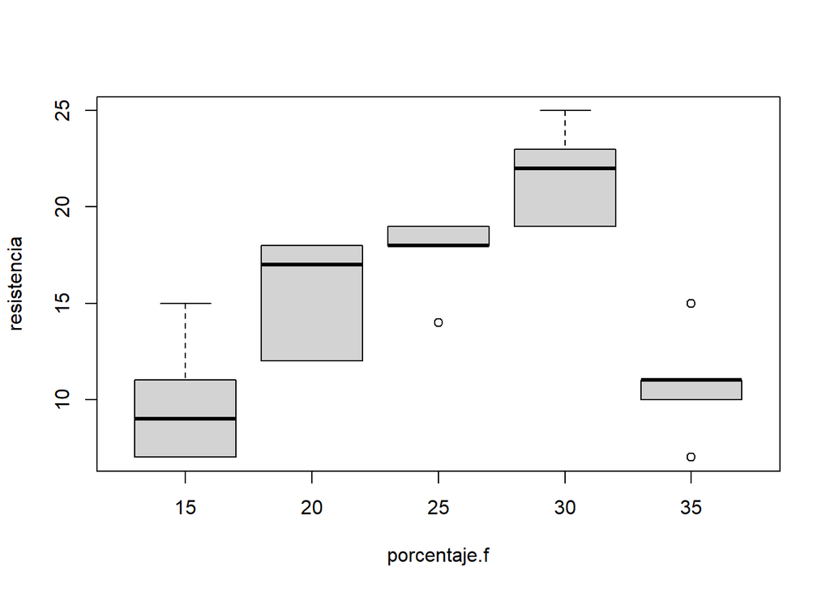

```r
porcentaje<-c(rep(15,5),rep(20,5),rep(25,5),rep(30,5),rep(35,5))
resistencia<-c(7,7,15,11,9,12,17,12,18,18,14,18,18,19,19,19,25,22,19,23,7,10,11,15,11)
porcAlgodon <-data.frame(porcentaje,resistencia)

porcentaje.f=factor(porcentaje)

plot(resistencia~porcentaje.f)# idem boxplot(resistencia~porcentaje.f)
```

```r
AOVporcAlgo<- aov(resistencia~porcentaje.f)
summary(AOVporcAlgo)#idem usando anova(AOVporcAlgo)
```

```
##              Df Sum Sq Mean Sq F value   Pr(>F)
## porcentaje.f  4  475.8  118.94   14.76 9.13e-06 ***
## Residuals    20  161.2    8.06
## ---
## Signif. codes:  0 '***' 0.001 '**' 0.01 '*' 0.05 '.' 0.1 ' ' 1
```

Aplicando ANOVA el p-valor=9.13e-06 es <0.05, por lo tanto, si se verifican los supuestos de normalidad y homogeneidad de la varianza será válido decir que se rechaza que las medias de cada grupo son todas iguales entre sí, es decir, hay al menos un par que difieren, por lo tanto los porcentajes de algodón influyen sobre la resistencia.

Veamos si se cumplen los supuestos necesarios para aplicar ANOVA.

#### Analizamos igualdad de varianzas:

```r
library(car)
bartlett.test(resistencia,porcentaje.f)
```

```
##
##  Bartlett test of homogeneity of variances
##
## data:  resistencia and porcentaje.f
## Bartlett's K-squared = 0.93309, df = 4, p-value = 0.9198
```

```r
leveneTest(resistencia~porcentaje.f)
```

|  | Df | F value | Pr(>F) |
| --- | --- | --- | --- |
| group | 4 | 0.3179487 | 0.8625859 |
|  | 20 | NA | NA |

#### Analizamos normalidad:

```r
shapiro.test(residuals(AOVporcAlgo))
```

```
##
##  Shapiro-Wilk normality test
##
## data:  residuals(AOVporcAlgo)
## W = 0.94387, p-value = 0.1818
```

```r
library(nortest)
ad.test(residuals(AOVporcAlgo))
```

```
##
##  Anderson-Darling normality test
##
## data:  residuals(AOVporcAlgo)
## A = 0.51857, p-value = 0.1699
```

```r
library(moments)
agostino.test(residuals(AOVporcAlgo))
```

```
##
##  D'Agostino skewness test
##
## data:  residuals(AOVporcAlgo)
## skew = 0.10554, z = 0.25734, p-value = 0.7969
## alternative hypothesis: data have a skewness
```

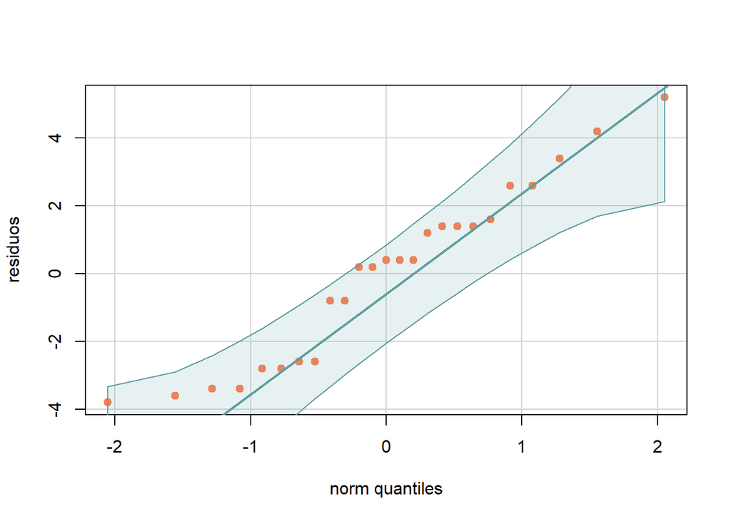

```r
qqPlot(residuals(AOVporcAlgo),ylab = "residuos", col = "coral",pch = 19, col.lines = "cadetblue",id=FALSE)
```

Los intervalos de confianza simultáneos para las diferencias de medias de Tukey resultan:

```r
TukeyHSD(AOVporcAlgo,conf.level=0.95)
```

```
##   Tukey multiple comparisons of means
##     95% family-wise confidence level
##
## Fit: aov(formula = resistencia ~ porcentaje.f)
##
## $porcentaje.f
##        diff         lwr        upr     p adj
## 20-15   5.6   0.2270417 10.9729583 0.0385024
## 25-15   7.8   2.4270417 13.1729583 0.0025948
## 30-15  11.8   6.4270417 17.1729583 0.0000190
## 35-15   1.0  -4.3729583  6.3729583 0.9797709
## 25-20   2.2  -3.1729583  7.5729583 0.7372438
## 30-20   6.2   0.8270417 11.5729583 0.0188936
## 35-20  -4.6  -9.9729583  0.7729583 0.1162970
## 30-25   4.0  -1.3729583  9.3729583 0.2101089
## 35-25  -6.8 -12.1729583 -1.4270417 0.0090646
## 35-30 -10.8 -16.1729583 -5.4270417 0.0000624
```

¿Qué conclusión obtenemos?

## ANOVA de 1 factor utilizando transformaciones de Box-Cox

Con la intención de evaluar la eficacia de un medicamento en el nivel de alerta de unos pacientes, tres dosis (a, b, c) de un determinado fármaco se administraron a 18 sujetos. Se pide analizar la eficacia del medicamento.

```r
dosis<-c(rep("a",6),rep("b",8),rep("c",4))
alerta<-c(30,38,35,41,27,24,32,26,31,29,27,35,21,25,17,21,20,19)
data<-data.frame(dosis,alerta)
head(data,8)
```

|  | dosis | alerta |
| --- | --- | --- |
| 1 | a | 30 |
| 2 | a | 38 |
| 3 | a | 35 |
| 4 | a | 41 |
| 5 | a | 27 |
| 6 | a | 24 |
| 7 | b | 32 |
| 8 | b | 26 |

Para analizar la eficacia del medicamento, veamos si existen diferencias entre las medias de las tres dosis. Aplicamos ANOVA.

```r
aov.data<-aov(alerta~dosis,data=data)
summary(aov.data)
```

```
##             Df Sum Sq Mean Sq F value  Pr(>F)
## dosis        2  426.2  213.12   8.789 0.00298 **
## Residuals   15  363.8   24.25
## ---
## Signif. codes:  0 '***' 0.001 '**' 0.01 '*' 0.05 '.' 0.1 ' ' 1
```

Se puede ver que existen diferencias estadísticamente significativas entre los niveles del fármaco (p=0.00298 <0.05). Para asegurar la validez de esta afirmación realizamos las siguientes pruebas diagnósticas.

La siguiente tabla muestra las medias total y por nivel de los 3 medicamentos:

```r
print(model.tables(aov.data,"means"))
```

```
## Tables of means
## Grand mean
##
## 27.66667
##
##  dosis
##        a     b     c
##     32.5 28.25 19.25
## rep  6.0  8.00  4.00
```

#### Analizamos normalidad:

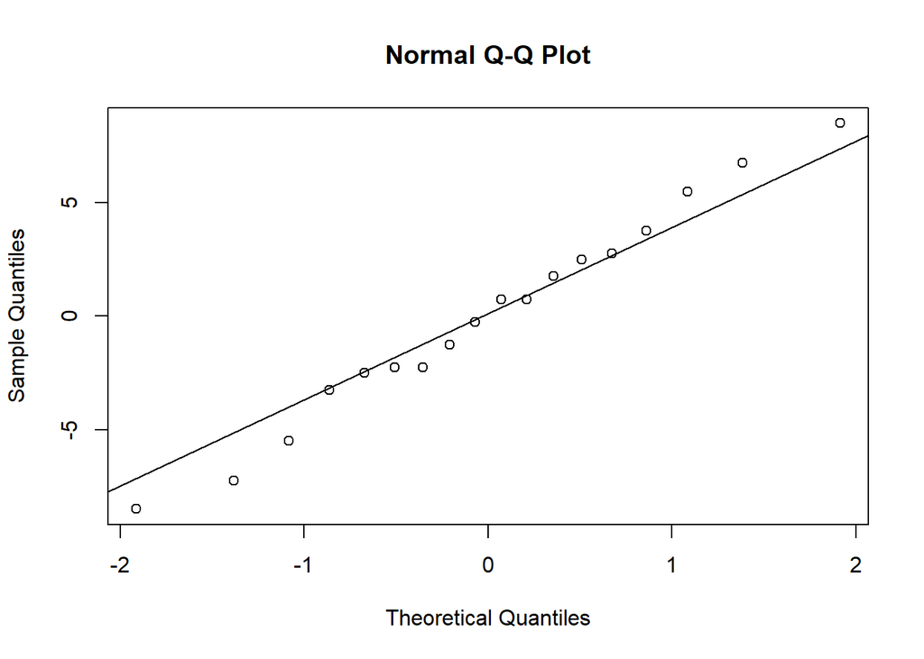

```r
qqnorm(resid(aov.data))
qqline(resid(aov.data))
```

```r
shapiro.test(residuals(aov.data))
```

```
##
##  Shapiro-Wilk normality test
##
## data:  residuals(aov.data)
## W = 0.98604, p-value = 0.991
```

```r
ad.test(residuals(aov.data))
```

```
##
##  Anderson-Darling normality test
##
## data:  residuals(aov.data)
## A = 0.11805, p-value = 0.987
```

#### Analizamos igualdad de varianzas (homoscedasticidad):

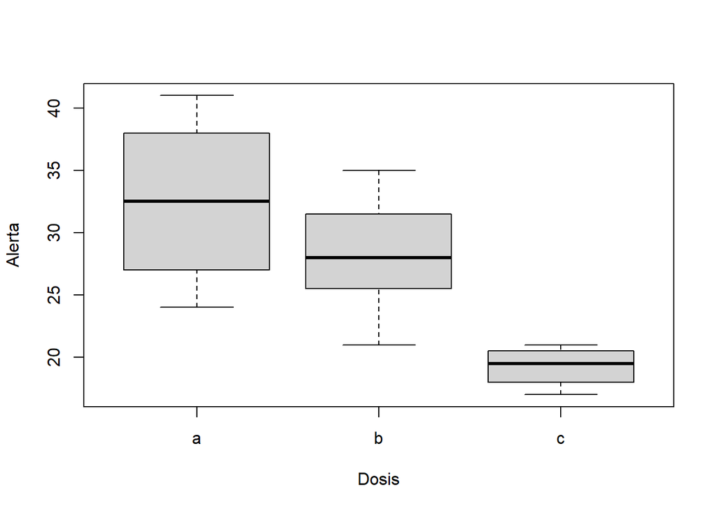

```r
boxplot(split(data$alerta,data$dosis),ylab="Alerta",xlab="Dosis")
```

Las varianzas estimadas en cada grupo son:

```r
tapply(data$alerta,data$dosis,var,na.rm=TRUE)
```

```
##         a         b         c
## 43.500000 19.642857  2.916667
```

```r
bartlett.test(alerta,dosis)
```

```
##
##  Bartlett test of homogeneity of variances
##
## data:  alerta and dosis
## Bartlett's K-squared = 4.4546, df = 2, p-value = 0.1078
```

```r
leveneTest(alerta~as.factor(dosis))
```

|  | Df | F value | Pr(>F) |
| --- | --- | --- | --- |
| group | 2 | 4.166667 | 0.03637965 |
|  | 15 | NA | NA |

OJO: Hay que tener en cuenta el tamaño muestral, cuando el tamaño de la muestra es pequeño, incluso grandes desviaciones de la normal no se detectan, y cuando el tamaño de la muestra es grande, incluso la más mínima desviación de la normalidad logra rechazar la hipótesis nula. En este caso, al ser la muestra pequeña y el test de Bartlett sensible a las desviaciones de la normalidad, este test no detecta diferencia de varianzas (heterocedasticidad) en los niveles del factor (dosis). Por eso, es conveniente utilizar el test de Levene, el cual rechaza la homoscedasticidad, lo que indica que NO se cumple uno de los supuestos del ANOVA.

Para resolver este problema, puede ser útil alguna transformación de Box-Cox:

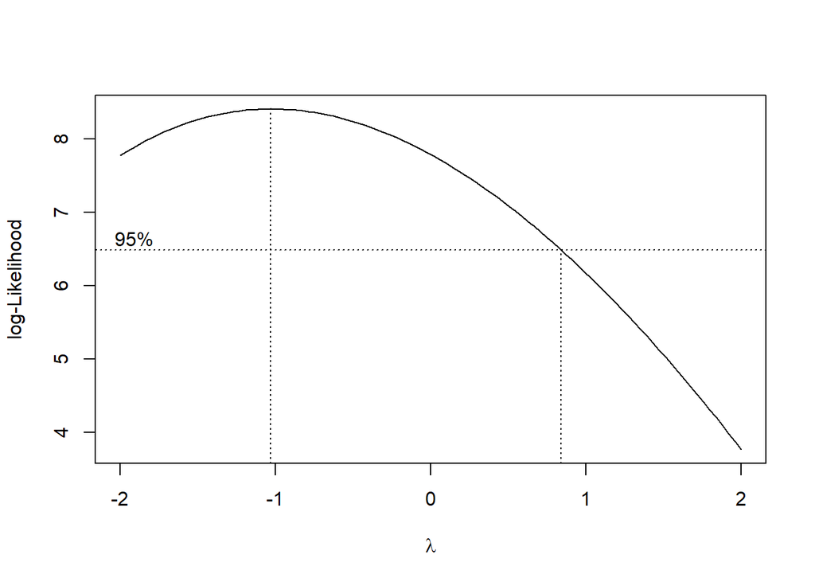

```r
#library(MASS)
boxcox(alerta~dosis,data=data,plotit=TRUE)# el máximo se alcanza en lambda -1.
```

```r
#bc<-boxcox(alerta~dosis,data=data,plotit=FALSE)# el máximo se alcanza
#bc$x[bc$y==max(bc$y)]#-1
```

Se repite el procedimiento para la variable transformada, y se revisa el cumplimiento de supuestos para aplicar ANOVA.

```r
aov.data2=aov(alerta^(-1)~dosis,data=data)
summary(aov.data2)
```

```
##             Df    Sum Sq   Mean Sq F value   Pr(>F)
## dosis        2 0.0010623 0.0005311   14.64 0.000298 ***
## Residuals   15 0.0005442 0.0000363
## ---
## Signif. codes:  0 '***' 0.001 '**' 0.01 '*' 0.05 '.' 0.1 ' ' 1
```

Se obtiene, como con la variable original, diferencias estadísticamente significativas entre los niveles del factor dosis.

#### Revisión de supuestos necesarios para aplicar ANOVA:

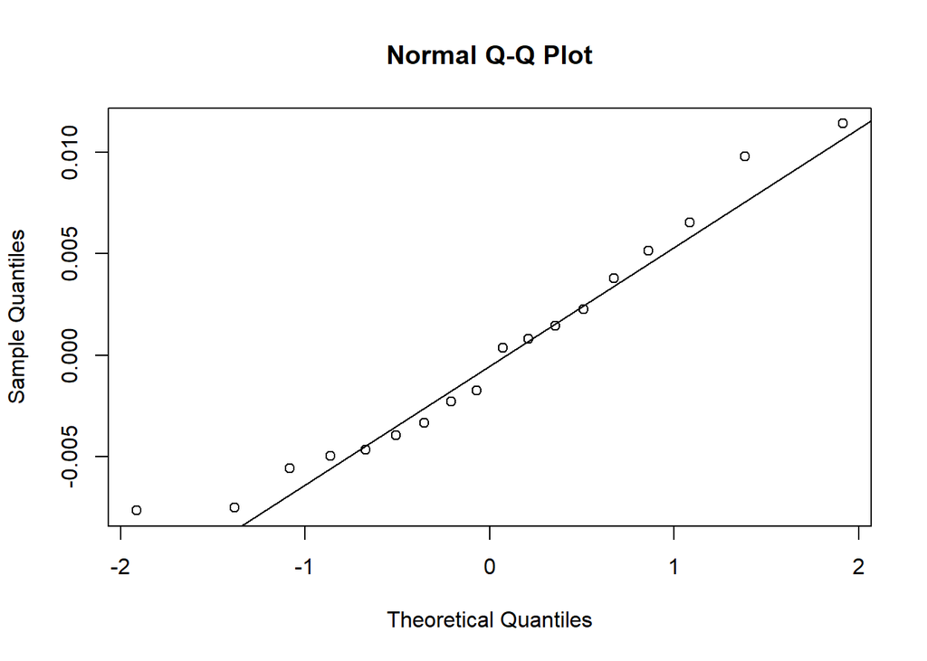

```r
qqnorm(resid(aov.data2))
qqline(resid(aov.data2))
```

```r
shapiro.test(residuals(aov.data2))
```

```
##
##  Shapiro-Wilk normality test
##
## data:  residuals(aov.data2)
## W = 0.95026, p-value = 0.4291
```

```r
ad.test(residuals(aov.data2))
```

```
##
##  Anderson-Darling normality test
##
## data:  residuals(aov.data2)
## A = 0.29018, p-value = 0.5706
```

```r
leveneTest(alerta^(-1)~as.factor(dosis),data=data)
```

|  | Df | F value | Pr(>F) |
| --- | --- | --- | --- |
| group | 2 | 0.449561 | 0.6462282 |
|  | 15 | NA | NA |

Con la transformación de Box-Cox realizada se verifican los supuestos necesarios y por lo tanto el resultado del ANOVA aplicado es válido.

Los intervalos de confianza simultáneos para las diferencias de medias de Tukey resultan:

```r
TukeyHSD(aov.data2,conf.level=0.95)
```

```
##   Tukey multiple comparisons of means
##     95% family-wise confidence level
##
## Fit: aov(formula = alerta^(-1) ~ dosis, data = data)
##
## $dosis
##            diff          lwr        upr     p adj
## b-a 0.004324235 -0.004125103 0.01277357 0.4013805
## c-a 0.020382789  0.010283900 0.03048168 0.0002760
## c-b 0.016058555  0.006477907 0.02563920 0.0015462
```

## Test no paramétrico de Kruskal Wallis

Un estudio compara el número de huevos que pone un determinado insecto bajo 3 condiciones distintas. ¿Existen diferencias significativas dependiendo de las condiciones?

```r
datos <- data.frame(condicion = c(rep("condicion1", 18), rep("condicion2", 18), rep("condicion3", 18)), n_huevos = c(1, 2, 3, 4, 5, 6, 7, 8, 9, 16, 27, 28, 29, 30, 51, 52, 53, 342, 40, 41, 42, 43, 44, 45, 46, 47, 48, 67, 88, 89, 90, 91, 92, 93, 94, 293, 19, 20, 21, 22, 23, 24, 25, 26, 27, 28, 25, 36, 37, 58, 59, 60, 71, 72))
head(datos)
```

|  | condicion | n_huevos |
| --- | --- | --- |
| 1 | condicion1 | 1 |
| 2 | condicion1 | 2 |
| 3 | condicion1 | 3 |
| 4 | condicion1 | 4 |
| 5 | condicion1 | 5 |
| 6 | condicion1 | 6 |

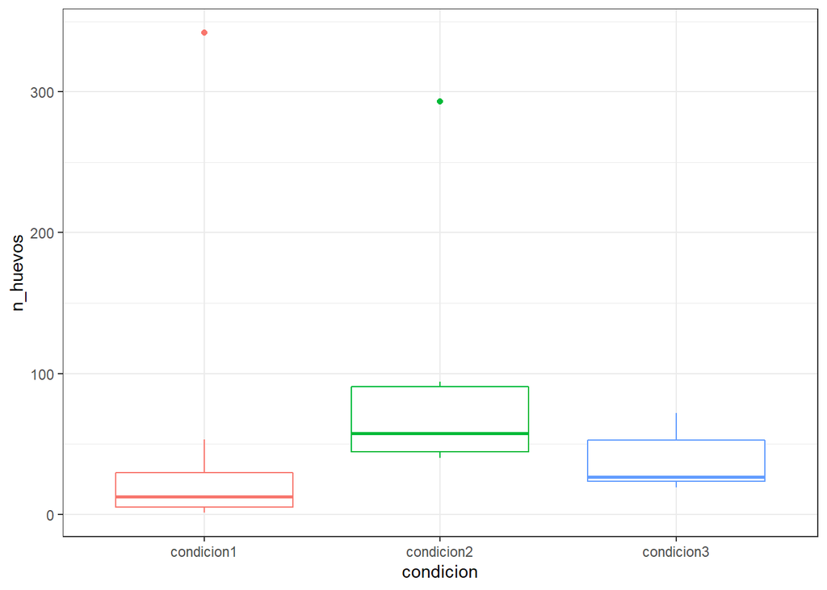

```r
ggplot(data = datos, mapping = aes(x = condicion, y = n_huevos, colour = condicion)) +
  geom_boxplot() + theme_bw() + theme(legend.position = "none")
```

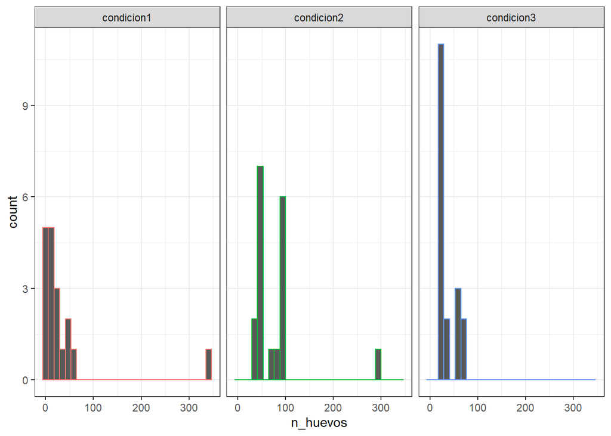

```r
ggplot(data = datos, mapping = aes(x = n_huevos, colour = condicion)) +
  geom_histogram() + theme_bw() + facet_grid(. ~ condicion) +
  theme(legend.position = "none")# + stat_bin(binwidth=30)
```

Aplicamos ANOVA.

```r
aov.datos<-aov(n_huevos~condicion,data=datos)
summary(aov.datos)
```

```
##             Df Sum Sq Mean Sq F value Pr(>F)
## condicion    2  19748    9874   3.005 0.0584 .
## Residuals   51 167600    3286
## ---
## Signif. codes:  0 '***' 0.001 '**' 0.01 '*' 0.05 '.' 0.1 ' ' 1
```

#### Analizamos los supuestos para la validez de ANOVA (normalidad y homoscedasticidad):

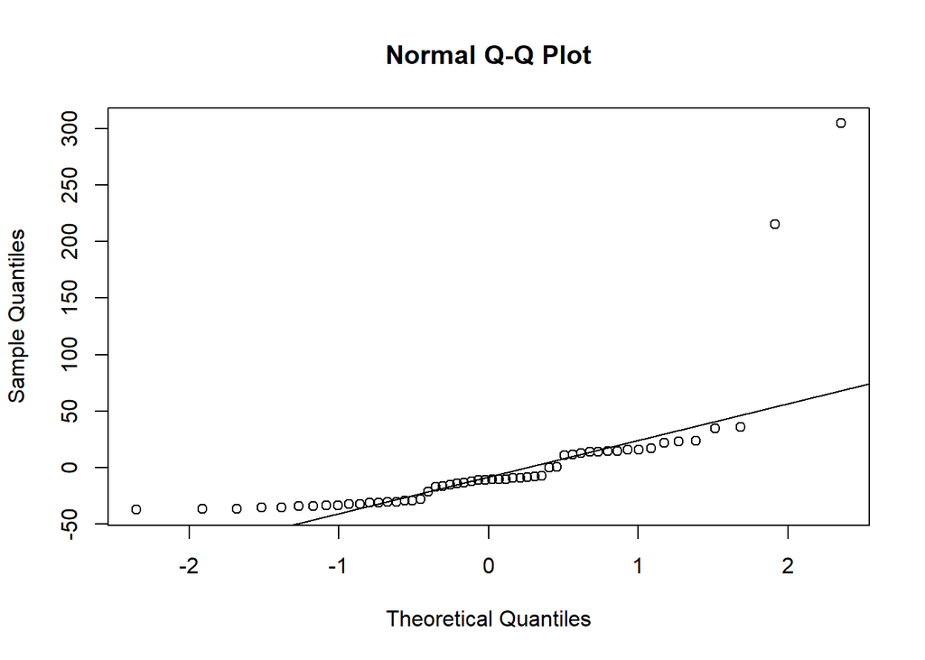

```r
qqnorm(resid(aov.datos))
qqline(resid(aov.datos))
```

```r
shapiro.test(residuals(aov.datos))
```

```
##
##  Shapiro-Wilk normality test
##
## data:  residuals(aov.datos)
## W = 0.52275, p-value = 5.411e-12
```

```r
leveneTest(n_huevos ~ condicion, data = datos)
```

|  | Df | F value | Pr(>F) |
| --- | --- | --- | --- |
| group | 2 | 0.7929454 | 0.458009 |
|  | 51 | NA | NA |

No se cumplen los supuestos para la validez de ANOVA.

#### Una alternativa en caso de que no se cumplan los supuestos para la aplicación de ANOVA ni en los datos originales ni en los transformados:

```r
kruskal.test(n_huevos ~ condicion, data = datos)
```

```
##
##  Kruskal-Wallis rank sum test
##
## data:  n_huevos by condicion
## Kruskal-Wallis chi-squared = 19.964, df = 2, p-value = 4.623e-05
```

```r
#library(pgirmess)
kruskalmc(datos$n_huevos ~ datos$condicion)
```

```
## Multiple comparison test after Kruskal-Wallis
## p.value: 0.05
## Comparisons
##                         obs.dif critical.dif difference
## condicion1-condicion2 22.888889     12.55414       TRUE
## condicion1-condicion3  7.111111     12.55414      FALSE
## condicion2-condicion3 15.777778     12.55414       TRUE
```

## ANOVA de 2 factores

### Ejemplo

Supóngase un estudio clínico que analiza la eficacia de un medicamento teniendo en cuenta dos factores, el sexo (masculino y femenino) y la edad (joven, adulto). Se quiere analizar si el efecto es diferente entre alguno de los niveles de cada variable por si sola o en combinación.

```r
individuo <- as.factor(c(1, 2, 3, 4, 5, 6, 7, 8, 9, 10, 11, 12, 13, 14, 15, 16, 17, 18, 19, 20, 21, 22, 23, 24, 25, 26, 27, 28, 29, 30))
sexo <- c("mujer", "hombre", "hombre", "mujer", "hombre", "hombre", "hombre", "mujer", "mujer", "hombre", "hombre", "hombre", "hombre", "mujer", "mujer", "mujer", "hombre", "mujer", "mujer", "hombre", "hombre", "mujer", "hombre", "hombre", "hombre", "hombre", "hombre", "hombre", "mujer", "hombre")
edad <- c("adulto", "adulto", "adulto", "adulto", "adulto", "adulto", "joven", "joven", "adulto", "joven", "joven", "adulto", "joven", "joven", "joven", "adulto", "joven", "adulto", "joven", "joven", "joven", "joven", "adulto", "joven", "joven", "joven", "joven", "joven", "joven", "adulto")
resultado <- c(7.1, 11, 5.8, 8.8, 8.6, 8, 3, 5.2, 3.4, 4, 5.3, 11.3, 4.6, 6.4, 13.5, 4.7, 5.1, 7.3, 9.5, 5.4, 3.7, 6.2, 10, 1.7, 2.9, 3.2, 4.7, 4.9, 9.8, 9.4)
datos <- data.frame(individuo, sexo, edad, resultado)
head(datos, 4)
```

|  | individuo | sexo | edad | resultado |
| --- | --- | --- | --- | --- |
| 1 | 1 | mujer | adulto | 7.1 |
| 2 | 2 | hombre | adulto | 11.0 |
| 3 | 3 | hombre | adulto | 5.8 |
| 4 | 4 | mujer | adulto | 8.8 |

Comparamos los resultados según los niveles de ambas categorías.

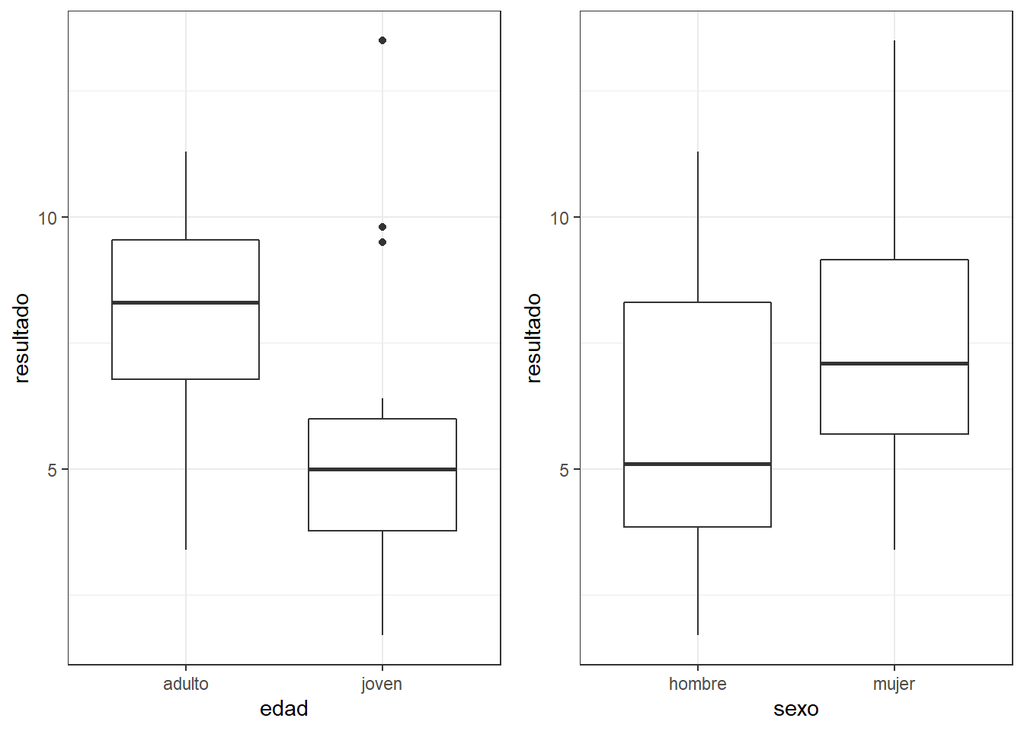

```r
library(ggplot2)
library(gridExtra)

p1 <- ggplot(data = datos, mapping = aes(x = edad, y = resultado)) + geom_boxplot() +
  theme_bw()
p2 <- ggplot(data = datos, mapping = aes(x = sexo, y = resultado)) + geom_boxplot() +
  theme_bw()
p3 <- ggplot(data = datos, mapping = aes(x = edad, y = resultado, colour = sexo)) +
  geom_boxplot() + theme_bw()
grid.arrange(p1, p2, ncol = 2)
```

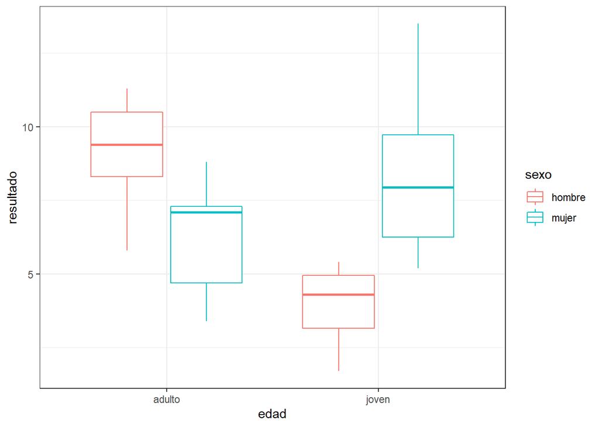

```r
p3
```

Analizamos interacciones.

```r
with(data = datos, expr = tapply(resultado, sexo, mean))
```

```
##   hombre    mujer
## 5.926316 7.445455
```

```r
with(data = datos, expr = tapply(resultado, sexo, sd))
```

```
##   hombre    mujer
## 2.906858 2.828202
```

```r
with(data = datos, expr = tapply(resultado, edad, mean))
```

```
##   adulto    joven
## 7.950000 5.505556
```

```r
with(data = datos, expr = tapply(resultado, edad, sd))
```

```
##   adulto    joven
## 2.431049 2.871047
```

```r
with(data = datos, expr = tapply(resultado, list(sexo, edad), mean))
```

```
##          adulto    joven
## hombre 9.157143 4.041667
## mujer  6.260000 8.433333
```

```r
with(data = datos, expr = tapply(resultado, list(sexo, edad), sd))
```

```
##          adulto    joven
## hombre 1.900752 1.157158
## mujer  2.170944 3.106552
```

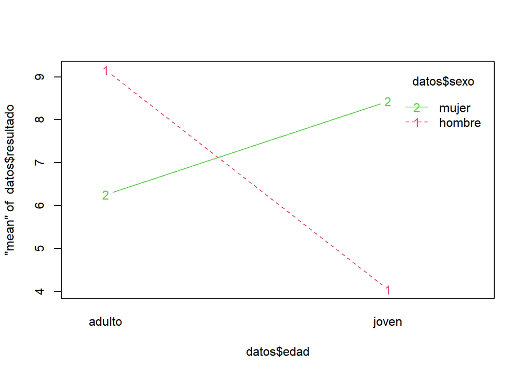

```r
interaction.plot(trace.factor = datos$sexo, x.factor = datos$edad, response = datos$resultado, fun = "mean", legend = TRUE, col = 2:3, type = "b")
```

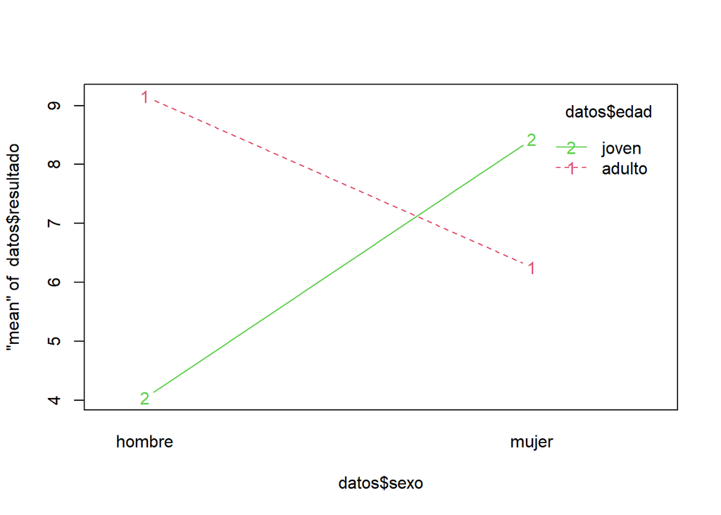

```r
interaction.plot(trace.factor = datos$edad, x.factor = datos$sexo, response = datos$resultado, fun = "mean", legend = TRUE, col = 2:3, type = "b")
```

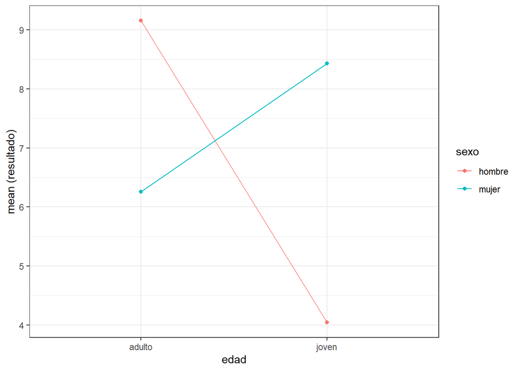

```r
ggplot(data = datos, aes(x = edad, y = resultado, colour = sexo, group = sexo)) +
  stat_summary(fun.y = mean, geom = "point") + stat_summary(fun.y = mean, geom = "line") +
  labs(y = "mean (resultado)") + theme_bw()
```

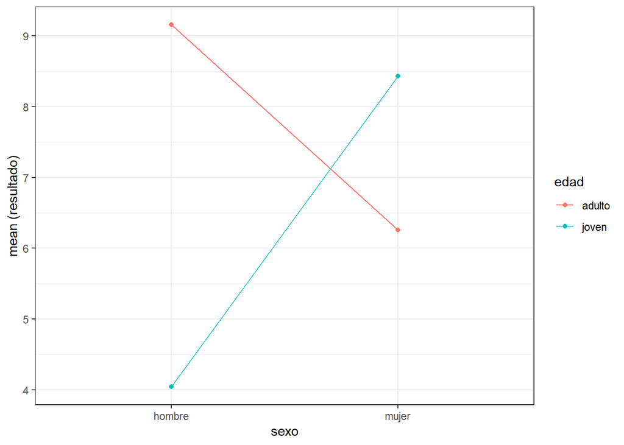

```r
ggplot(data = datos, aes(x = sexo, y = resultado, colour = edad, group = edad)) +
  stat_summary(fun.y = mean, geom = "point") + stat_summary(fun.y = mean, geom = "line") +
  labs(y = "mean (resultado)") + theme_bw()
```

```r
anova_2vias <- aov(formula = resultado ~ sexo*edad, data = datos)
summary(anova_2vias)
```

```
##             Df Sum Sq Mean Sq F value  Pr(>F)
## sexo         1  16.08   16.08   4.038  0.0550 .
## edad         1  38.96   38.96   9.786  0.0043 **
## sexo:edad    1  89.61   89.61  22.509 6.6e-05 ***
## Residuals   26 103.51    3.98
## ---
## Signif. codes:  0 '***' 0.001 '**' 0.01 '*' 0.05 '.' 0.1 ' ' 1
```

```r
library(lsr)
etaSquared(anova_2vias)
```

```
##               eta.sq eta.sq.part
## sexo      0.04842176   0.1040130
## edad      0.15699885   0.2734635
## sexo:edad 0.36110080   0.4640119
```

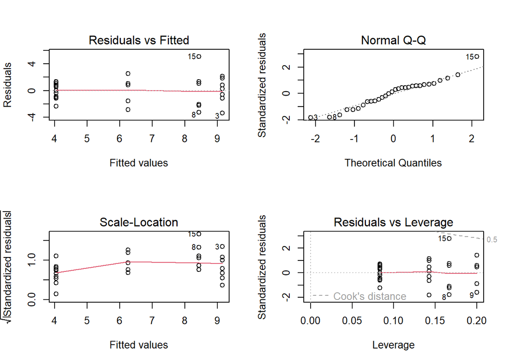

```r
par(mfrow = c(2,2))
plot(anova_2vias)
```

```r
par(mfrow = c(1,1))
```

La observacion 15 es un outlier según los gráficos anteriores, se podría probar sacarla…